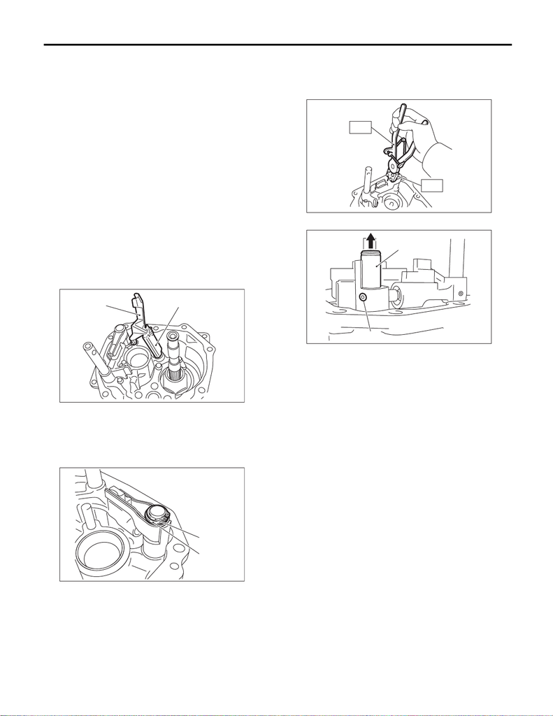

6MT(TY85)-57

Transmission Case

MANUAL TRANSMISSION AND DIFFERENTIAL

18.Transmission Case

A: REMOVAL

1) Remove the manual transmission assembly

from the vehicle. <Ref. to 6MT(TY85)-31, REMOV-

AL, Manual Transmission Assembly.>

2) Prepare the transmission for overhaul. <Ref. to

6MT(TY85)-38, Preparation for Overhaul.>

3) Remove the neutral position switch, back-up

light switch and harness. <Ref. to 6MT(TY85)-41,

REMOVAL, Neutral Position Switch.> <Ref. to

6MT(TY85)-40, REMOVAL, Back-up Light

Switch.>

4) Remove the extension case. <Ref. to

6MT(TY85)-42, REMOVAL, Extension Case.>

5) Remove the transfer driven gear. <Ref. to

6MT(TY85)-54, REMOVAL, Transfer Driven

Gear.>

6) Remove the center differential. <Ref. to

6MT(TY85)-56, REMOVAL, Center Differential.>

7) Remove the oil guides G and H.

8) Remove the snap ring and flat washer from the

selector arm area.

9) Using an ST, remove the neutral set spring and

support.

ST1 18756AA000 CLAW

ST2 399893600 PLIER

10) Lift the striking rod, and remove the straight pin.

(A) Oil guide G

(B) Oil guide H

(A) Snap ring

(B) Flat washer

MT-01728

(A)

(B)

MT-01616

(B)

(A)

(A) Striking rod

(B) Straight pin

MT-01092

ST2

ST1

MT-01307

(A)

(B)

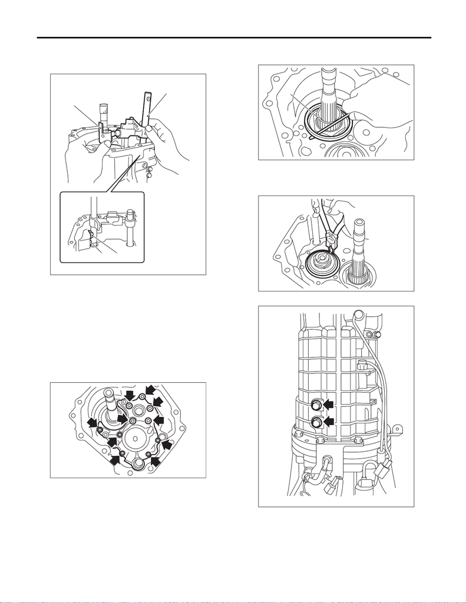

6MT(TY85)-58

Transmission Case

MANUAL TRANSMISSION AND DIFFERENTIAL

11) Remove the selector arm No. 2, shifter arm

shaft, selector plunger, shift accent plunger and

spring.

12) Remove the transfer bearing holder.

NOTE:

Using a general tool may cause damage. Remove

the bolt using the ST.

ST 18663AA000 SOCKET

13) Remove the washer on the main shaft section.

15) Remove the snap ring.

16) Remove the pilot bolt.

(A) Selector arm No. 2

(B) Shifter arm shaft

(C) Selector plunger

(D) Shift accent plunger

MT-03101

(B)

(A)

(C)(D)

MT-01619

(A) Driven gear ASSY

(A)

MT-00526

MT-00527

MT-00528

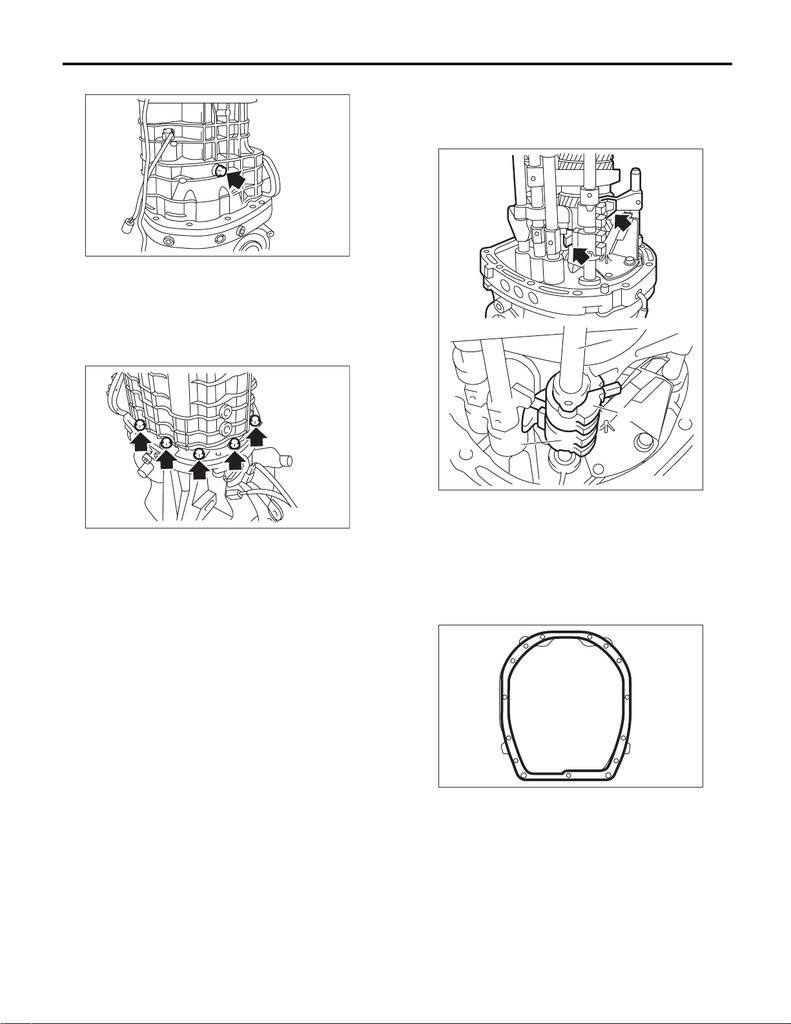

6MT(TY85)-59

Transmission Case

MANUAL TRANSMISSION AND DIFFERENTIAL

17) Remove the holder reverse bolt.

18) Remove the transmission case.

NOTE:

If the oil guide is caught between the shift fork, it

may be difficult to remove the transmission case.

Move the oil guide, then remove. Do not pull on the

transmission case with excessive force.

19) Remove any remaining liquid gasket from the

transmission case and adapter plate.

B: INSTALLATION

1) Check that the shifter fork and the interlock block

are both shifted into the neutral position. If they are

not, shift into the neutral position.

2) Apply liquid gasket to the adapter plate.

Liquid gasket:

THREE BOND 1215B or equivalent

3) Install the transmission case.

MT-00529

MT-01711

(A) Striking rod

(B) Reverse interlock block

(C) Interlock block

(A)

(C)

(B)

MT-01620

MT-00532

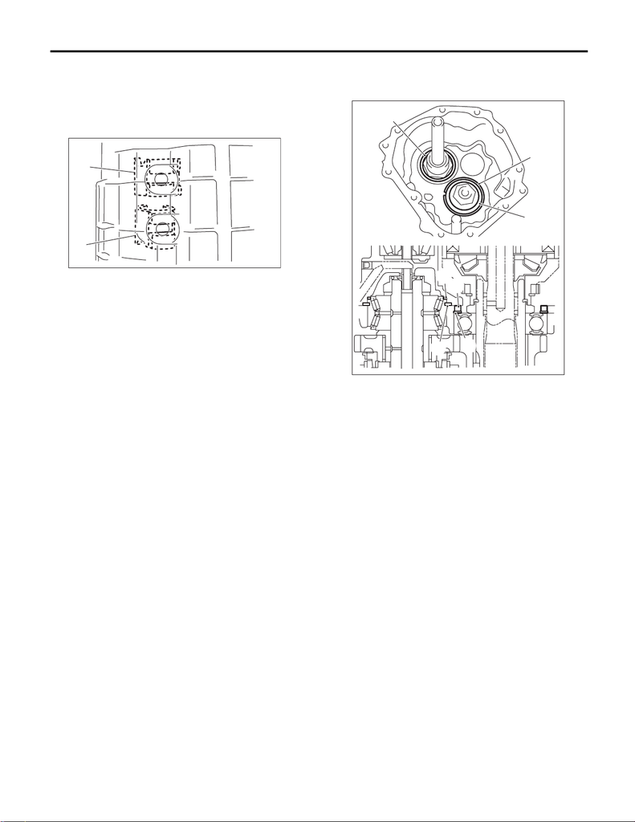

6MT(TY85)-60

Transmission Case

MANUAL TRANSMISSION AND DIFFERENTIAL

4) By inspecting from the pilot bolt attachment hole,

check that the interlock block and the reverse inter-

lock block are aligned to the neutral position. If not

aligned, remove the transmission case, and shift

the shifter fork and interlock block to the neutral po-

sition.

5) Use a new gasket to temporarily attach the pilot

bolt.

6) Affix the transmission case with the bolts and

nuts.

Tightening torque:

50 N·m (5.1 kgf-m, 36.9 ft-lb)

7) Tighten the pilot bolt.

Tightening torque:

34 N·m (3.5 kgf-m, 25.1 ft-lb)

8) Tighten the holder reverse bolt.

Tightening torque:

25 N·m (2.5 kgf-m, 18.4 ft-lb)

9) Install the snap ring and washer for the main

shaft assembly, and washer and collar for the driv-

en gear assembly.

10) Install the transfer bearing holder.

Tightening torque:

25 N·m (2.5 kgf-m, 18.4 ft-lb)

ST 18663AA000 SOCKET

11) When replacing the transfer bearing holder, se-

lect the appropriate transfer driven gear and adjust-

ing washer, and install to the extension case. <Ref.

to 6MT(TY85)-44, ADJUSTMENT, Extension

Case.>

12) Install the selector arm No. 2, shifter arm shaft,

selector plunger, shift accent plunger and spring.

13) Install a new straight pin.

14) Using the ST, install the neutral set spring.

ST1 18756AA000 CLAW

ST2 399893600 PLIER

15) Install the snap ring and flat washer to the se-

lector arm area.

16) Install the oil guides G and H.

17) Install the center differential. <Ref. to

6MT(TY85)-56, INSTALLATION, Center Differen-

tial.>

18) Install the transfer driven gear. <Ref. to

6MT(TY85)-54, INSTALLATION, Transfer Driven

Gear.>

(A) Interlock block

(B) Reverse interlock block

MT-00533

(A)

(B)

(A) Washer

(B) Snap ring

(C) Collar

(D) Washer

(C)

(B)

(A)

(C)

(B)

(D)

(A)

MT-01621

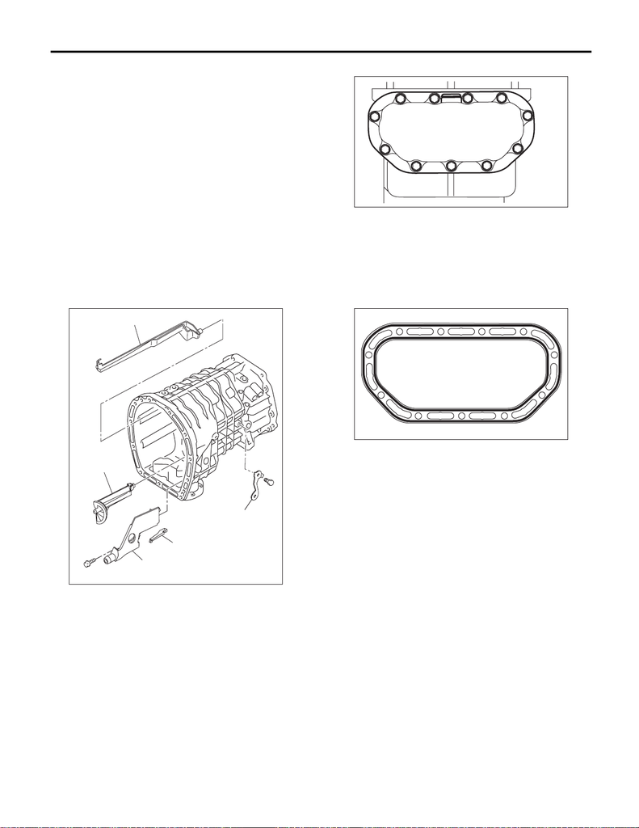

6MT(TY85)-61

Transmission Case

MANUAL TRANSMISSION AND DIFFERENTIAL

19) Install the extension case. <Ref. to 6MT(TY85)-

42, INSTALLATION, Extension Case.>

20) Install the neutral position switch, back-up light

switch and harness. <Ref. to 6MT(TY85)-41, IN-

STALLATION, Neutral Position Switch.> <Ref. to

6MT(TY85)-40, INSTALLATION, Back-up Light

Switch.>

21) Install the manual transmission assembly to the

vehicle. <Ref. to 6MT(TY85)-33, INSTALLATION,

Manual Transmission Assembly.>

C: DISASSEMBLY

1) Remove the transmission harness from the

transmission case.

NOTE:

Remove the connector by disengaging the connec-

tor claw from the inside of the transmission.

2) Remove the oil guides C, D, E, F and harness

bracket.

3) Remove the oil pan.

4) Remove any remaining liquid gasket from the

transmission case and oil pan.

D: ASSEMBLY

1) Apply liquid gasket to the oil pan.

Liquid gasket:

THREE BOND 1215B or equivalent

2) Install the oil pan.

Tightening torque:

6.4 N·m (0.7 kgf-m, 4.7 ft-lb)

(A) Oil guide C

(B) Oil guide D

(C) Oil guide E

(D) Oil guide F

(E) Harness bracket

(A)

(B)

(C)

(D)

MT-03075

(E)

MT-01831

MT-00541

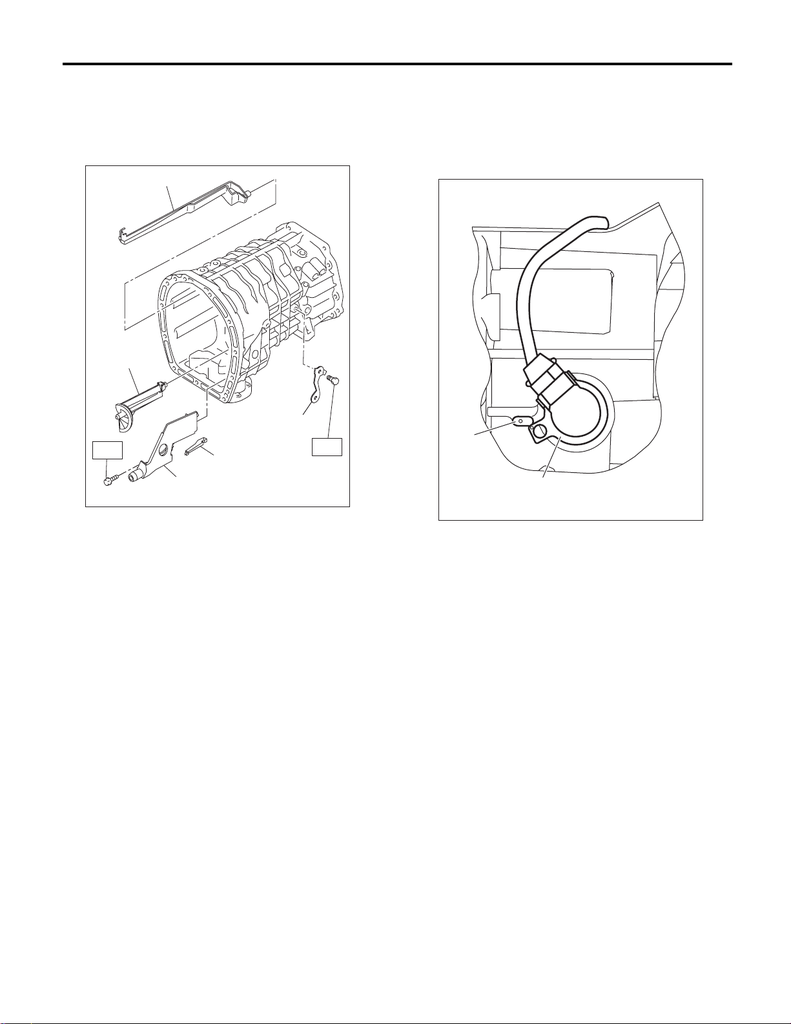

6MT(TY85)-62

Transmission Case

MANUAL TRANSMISSION AND DIFFERENTIAL

3) Install the oil guides C, D, E, F and harness

bracket.

Tightening torque:

T1: 16 N·m (1.6 kgf-m, 11.8 ft-lb)

T2: 18 N·m (1.8 kgf-m, 13.3 ft-lb)

4) Install the transmission harness to the transmis-

sion.

NOTE:

Install the transmission harness connector by align-

ing the protrusions of the transmission and trans-

mission harness connector.

E: INSPECTION

1) If the sludge is accumulated in the oil pan, use a

waste cloth to wipe it off completely.

2) Check that there is no damage on any parts. Re-

place damaged parts with new parts.

(A) Oil guide C

(B) Oil guide D

(C) Oil guide E

(D) Oil guide F

(E) Harness bracket

(A)

(B)

(C)

(D)

MT-03076

(E)

T1

T2

(A) Protrusion

(B) Transmission harness connectors

MT-01777

(B)

(A)